# Intro a conceptos de Ecologia

# Introducción

Como mencione anteriormente, la diversidad alfa es la diversidad media de especies en un sitio local. Este es el primer nivel de comparación de diversidad que van a usar para comparar sus muestras.

```r
library(microbiome)
```

# Indices de diversidad alfa

Calcular la diversidad alfa en realidad es bastante sencillo. El reto para ustedes sera interpretar estos datos:

La funcion base de phyloseq calcula 7 metodos diferentes para diversidad alfa:

1. *Observed:* cuenta el numero de especies por muestra (riqueza de especies)
2. *Chao1:* Estimador de riqueza de especie bajo la hipótesis de que las especies raras dan la mayor información sobre aquellas que no se observaron. Chao1 es usado por lo regular para muestras pequeñas y es particularmente útil en datos sesgados a especies de baja abundancia.
3. *ACE:* Abundance-based coverage estimator (ACE) es otro estimador no parametrico de riqueza de especie que usa la cobertura de la muestra, basado en la suma de las probabilidades de las especies observadas
4. *Shannon H’:* es un indice que integra tanto riqueza como uniformidad. Sin entrar en las matematicas Shannon le pone mas enfasis en sus calculos a la riqueza de especies como componente y a la cobertura de especies raras. (toma mas en cuenta la riqueza de las muestras)
5. *Simpson D1:* Es una medida de diversidad que tiene en cuenta el número de especies presentes, así como la abundancia relativa de cada especie. A medida que aumentan la riqueza y la uniformidad de las especies, también aumenta la diversidad. El valor de D oscila entre 0 y 1. El índice de Simpson pone mayor énfasis en el componente de uniformidad y en los tipos de cobertura dominantes. (entre mas cercano a 1 es mas uniforme, cercano a 0 menos especies)
6. Dado que Simpson mide la probabilidad de que dos individuos seleccionados aleatoriamente de una muestra pertenezcan a la misma especie (o a alguna categoría distinta de especie) tambien se puede calcular *InvSimpson*
7. *Fisher:* Este es un índice paramétrico de diversidad que supone que la abundancia de especies sigue la distribución de la serie logarítmica.

|  | Observed | Chao1 | se.chao1 | Simpson |
| --- | --- | --- | --- | --- |
| S81 | 3961 | 3992.752 | 7.124141 | 0.9993090 |
| S82 | 2371 | 2408.873 | 8.625932 | 0.9988061 |
| S83 | 3177 | 3236.052 | 10.743167 | 0.9989561 |
| S85 | 5249 | 5279.926 | 6.737617 | 0.9994519 |

## Otros indices de diversidad que pueden calcular

```r
# Del paquete breakway
chao_bunge(vid_bio, cutoff = 10) # similar a chao1 pero mas sensible, es mas sencillo. Se usaria cuando tengamos baja abundancia y gran porcentaje de muestras raras, para el numero de cutoff el defult es 10. entonces si lo quieres modificar que sea con un numero de cutoff donde no haya tanta diferencia en el estimate.
```

```
A collection of 4 alpha diversity estimates:

$ S81
Estimate of richness from method Chao-Bunge:
  Estimate is 4061
 with standard error 31.51
  Confidence interval: (3966, 6029)
  Cutoff:  10

$ S82
Estimate of richness from method Chao-Bunge:
  Estimate is 2452
 with standard error 25.99
  Confidence interval: (2375, 3890)
  Cutoff:  10

$ S83
Estimate of richness from method Chao-Bunge:
  Estimate is 3311
 with standard error 29.93
  Confidence interval: (3185, 5377)
  Cutoff:  10

$ S85
Estimate of richness from method Chao-Bunge:
  Estimate is 5374
 with standard error 35.43
  Confidence interval: (5255, 7855)
  Cutoff:  10
```

8. *Pielou:* Equalidad (tambien conocida como equidad de Pielou) es la diversidad de Shannon dividida por el logaritmo del numero de taxones. Esto mide la uniformidad con la que los individuos se dividen entre los taxones presentes.

*LOS QUE MAS VAMOS A USAR SERIA CHAO1 Y SHANNON*

[Mas info en indices de diversidad](https://www.nhm.uio.no/english/research/resources/past/help/diversity.html)

# Graficando diversidad alfa

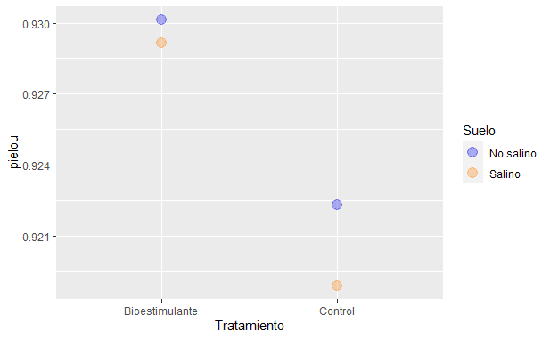

# Analisis estadistico

Como con los datos que vimos durante el modulo estadistico, el analisis estadistico seguira el mismo flujo de trabajo que vimos y lo debran elegir dependiendo de su numero de muestras, tratamientos, etc.

```r
# Shapiro
for (i in 3:16) { # cambia dependiendo de sus datos
  shapiro <- shapiro.test(alphadiv[,i])
  normal <- ifelse(shapiro[["p.value"]]>0.05, "YES", "NO")
  print(c(i,normal))
}
```

```
[1] "3"   "YES"
[1] "4"   "YES"
[1] "5"   "YES"
[1] "6"   "YES"
[1] "7"   "YES"
[1] "8"   "YES"
[1] "9"   "YES"
[1] "10"  "YES"
[1] "11"  "YES"
[1] "12" "NO"
[1] "13"  "YES"
[1] "14"  "YES"
[1] "15"  "YES"
[1] "16"  "YES"
```

Dado que yo tengo 2 tipos de variables independientes (tratamientos y tipos de planta), para mi analisis usare una ANOVA de 2 vias: “esto es en el caso de Isabel osea con sus muestras, en nuestro caso solo tenemos una muestra por persona por lo cual no podriamos usar un ANOVA de 2 vias”

```r
leveneTest(Observed~ Tratamiento * Suelo, # vari. indep
                       data = alphadiv)
```

```
Levene's Test for Homogeneity of Variance (center = median)
      Df F value Pr(>F)
group  3     NaN    NaN
       0
```

```r
Anova(ad_anova)
```

```
Error in Anova.lm(mod, ...) : residual df = 0
```

Dado que solo tenemos 1 muestra por tratamiento no es correcto calcular una ANOVA ya qu ela ANOVA usa *grupos*. Lo ideal en este caso seria tratar de agrupar nuestras muestras por variable y llevar a cabo una T de student:

```r
t.test(Observed ~ Tratamiento, data= alphadiv) # no signif
t.test(Chao1 ~ Tratamiento, data = alphadiv) # no signif
t.test(Shannon ~ Tratamiento, data = alphadiv) # no signifi
t.test(Simpson ~ Tratamiento, data = alphadiv) #significativo
t.test(pielou ~ Tratamiento, data = alphadiv) # no signif


# obserced y cho usan riqueza...shannon uniformidad...simpson toma en cuenta los dos
```

Ya que esperamos que la aplicacion de nuestro bioestumulante mejore la diversidad alfa sin importar el tipo de suelo y basados en Simpson si son diferentes

```r
t.test(Observed ~ Suelo, data = alphadiv) # no signif
t.test(Chao1 ~ Suelo, data = alphadiv) # no signif
t.test(Shannon ~ Suelo, data = alphadiv) # no signif
t.test(Simpson ~ Suelo, data = alphadiv) # no signif
t.test(pielou ~ Suelo, data = alphadiv) # no signif

# por lo tanto nos damos cuenta que, nuestro suelo salino y no salino no tiene diferencia, lo cual es bueno ya que al descartarlos como variables no afectamos el analisis
```

# Ejercicio final

Van a usar los datos de “GlobalPatterns” que comparan las comunidades mikcrobianas de 25 muestras ambientales y tres “comunidades simuladas” conocidas (un total de 9 tipos de muestras) a una profundidad promedio de 3,1 millones de lecturas por muestra. Con estos datos seguiran el flujo de trabajo que acabamos de ver y para el analisis estadistico compraran _“SampleType”. Para este ejercicio solo analicen y grafiquen Chao1 y Shannon.

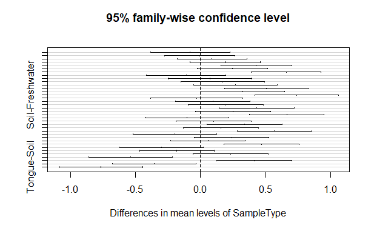